# Datavisualisering

Metode 1 F26 #5

Søren Damsbo-Svendsen

11. marts 2026

## Temaer

- plots / figurer / grafer / grafikker / datavisualisering
- {ggplot2}
  - geoms / plottyper
  - aesthetics
  - skalaer, facets, mv.
  - labels
  - temaer

## Hovedpointer

- *Datavisualisering er en effektiv metode* til at analysere og præsentere data og resultater
- Men meget at tage højde for, som kan føre til gode eller mindre gode datavisualiseringer
- Nemt at komme i gang med **{ggplot2}**
  - den grundlæggende grammatik er enkel
  - uendelige tilpasningsmuligheder
  - øvelse, øvelse, øvelse

## Plan for forelæsningen

1. Formålet med dataviz
2. **{ggplot2}**
3. (gg)plottets anatomi
4. (Mange) eksempler<sup>1</sup>
5. Principper for god datavisualisering
[^1]: **Data** fra seneste valgundersøgelse kan downloades på [Rigsarkivet](https://digidata.rigsarkivet.dk/aflevering/51035) – prøv selv

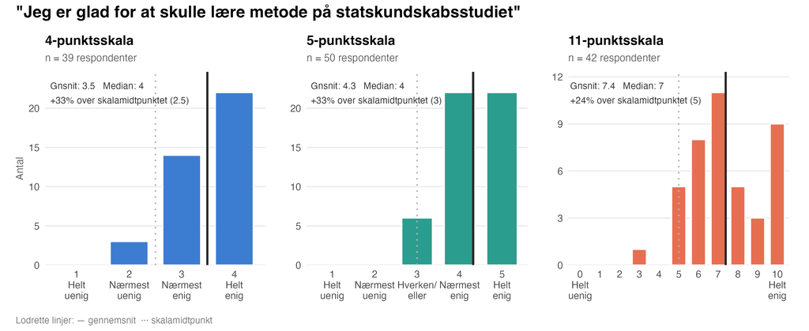

# Edward Tufte

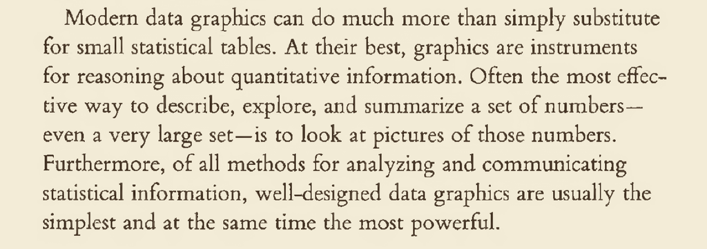

(Tufte 2001), ‘The Visual Display of Quantitative Information’

## Datavisualisering vs deskriptiv statistik

**Alternativer**

- Samme formål: beskrivelse/kommunikation af data
- Visualisere variablens fordeling i et søjlediagram vs. beregne gennemsnit, median og standardafvigelse

**Supplementer**

- Med statistik får vi sjældent indtryk af ‘helheden’ og overser mønstre
- Med grafer er det sjældent nemt at aflæse nøjagtige tal (tabeller/brødtekst er bedre)

**Kompleksitet**

- Datavisualisering kan kommunikere kondenseret information
  - fx mange statistikker: gennemsnit, medianer, forskelle, bivariate sammenhænge, effekter
  - evt. mange forskellige variable
- Tal overvælder nemt, grafik er mere overskueligt – og mere gribende

## Formål med dataviz

1. **At visualisere et enkelt budskab**
   - fx et (sæt af) forskningsresultat(er), hypotesetest, trend, sammenligning
   - det er et stykke **kommunikation** (hvem er publikum, hvem er afsender?)
2. At **fremlægge data på en transparent måde**
   - enkelte definerede dimensioner, men flere mulige budskaber / mønstre
   - handler om gennemsigtighed og empowerment af “læseren”
   - og/eller et arbejdsredskab i selve analysen
3. Sekundære formål / fordele:
   - Mindre tekst
   - Mere interessant og mindeværdigt
   - Æstetisk præference
4. Uanset formålet, må datavisualisering aldrig vildlede (for meget)

## Hvad er datavisualisering og {ggplot2} *ikke* er

- **Altid visualisering af *data* – rå, bearbejdet eller resultater**
- Ikke design af *grafik, der ikke er data*:
  - fx figurer til overblik over ideer, design, teori, projekt
- Ikke ideelt til at teste hypoteser
- Ikke tilstrækkeligt til avancerede analyser:
  - fx kausal inferens (påvirker x y?)
  - omend resultaterne ofte – også – visualiseres (supplerende)
- Ikke så **normreguleret**
  - få gode konventioner, om hvordan vi *bør* kommunikere data
  - praktisk / hands-on tilgang

# {ggplot2}

> “*Graphics reveal data. Indeed graphics can be more precise and revealing than conventional statistical computations*”

(Tufte 2001), ‘The Visual Display of Quantitative Information’

## ggplot2 i sidste forelæsning (#4)

**Kode**

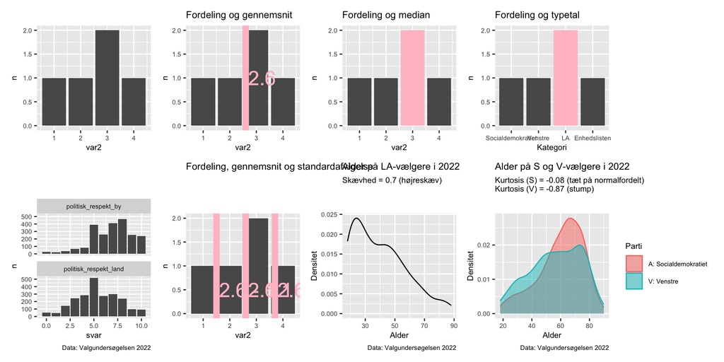

```r
set.seed(25)
df <- tibble(var1 = sample(letters[1:5], 5, replace = TRUE),
             var2 = sample(1:5, 5, replace = TRUE),
             var3 = runif(5, min = 1, max = 100)) |>
  mutate(enhed_nr = row_number(), .before = everything())

p1 <- df |>
  count(var2) |>
  ggplot() +
  aes(x = var2, y = n) +
  geom_col()

p2 <- df |>
  count(var2) |>
  ggplot() +
  aes(x = var2, y = n) +
  geom_col() +
  geom_vline(aes(xintercept = mean(df$var2)), linewidth = 3, color = "pink") +
  geom_text(aes(x = mean(df$var2) + .1, y = 1, label = mean(df$var2)), color = "pink", hjust = "left", size = 7) +
  labs(title = "Fordeling og gennemsnit")

p3 <- df |>
  count(var2) |>
  mutate(median_obs = var2 == median(df$var2)) |>
  ggplot() +
  aes(x = var2, y = n, fill = median_obs) +
  geom_col() +
  scale_fill_manual(values = c("grey35", "pink")) +
  guides(fill = "none") +
  labs(title = "Fordeling og median")

p4 <- df |>
  count(var2) |>
  mutate(median_obs = var2 == median(df$var2)) |>
  ggplot() +
  aes(x = factor(var2,
                 labels = c("Socialdemokratiet", "Venstre", "LA", "Enhedslisten")),
      y = n, fill = median_obs) +
  geom_col() +
  scale_fill_manual(values = c("grey35", "pink")) +
  guides(fill = "none") +
  labs(title = "Fordeling og typetal", x = "Kategori")

pdata_respekt <- vu |>
  mutate(politisk_respekt_land = ifelse(Q36_2 %in% 0:10, Q36_2, NA),
         politisk_respekt_by = ifelse(Q36_7 %in% 0:10, Q36_7, NA)) |>
  select(politisk_respekt_land, politisk_respekt_by) |>
  pivot_longer(cols = c(politisk_respekt_land, politisk_respekt_by), names_to = "var", values_to = "svar")

p5 <- pdata_respekt |>
  count(var, svar) |>
  ggplot() +
  aes(x = svar, y = n) +
  geom_col() +
  facet_wrap(~ var, ncol = 1) +
  labs(caption = "Data: Valgundersøgelsen 2022")

gns <- round(mean(df$var2), 1)
std_afvigelse <- round(sd(df$var2), 1)

p6 <- df |>
  count(var2) |>
  ggplot() +
  aes(x = var2, y = n) +
  geom_col() +
  geom_vline(aes(xintercept = gns), linewidth = 3, color = "pink") +
  geom_vline(aes(xintercept = gns - std_afvigelse), linewidth = 3, color = "pink") +
  geom_vline(aes(xintercept = gns + std_afvigelse), linewidth = 3, color = "pink") +
  geom_text(aes(x = gns + .1, y = .5, label = gns), color = "pink", hjust = "left", size = 7) +
  geom_text(aes(x = gns + std_afvigelse + .1, y = .5, label = paste0(gns, " + ", std_afvigelse)), color = "pink", hjust = "left", size = 7) +
  geom_text(aes(x = gns - std_afvigelse + .1, y = .5, label = paste0(gns, " - ", std_afvigelse)), color = "pink", hjust = "left", size = 7) +
  labs(title = paste0("Fordeling, gennemsnit og standardafvigelse"))

pdata <- vu |>
  mutate(x = ifelse(alder_på_valgdag %in% 18:98, alder_på_valgdag, NA)) |>
  filter(!is.na(x), parti22 %in% 9)

p7 <- pdata |>
  ggplot() +
  aes(x = x) +
  geom_density() +
  labs(x = "Alder", y = "Densitet", title = "Alder på LA-vælgere i 2022", subtitle = paste0("Skævhed = ", round(moments::skewness(pdata$x), 2), " (højreskæv)"), caption = "Data: Valgundersøgelsen 2022")

pdata <- vu |>
  mutate(x = ifelse(alder_på_valgdag %in% 18:98, alder_på_valgdag, NA)) |>
  filter(!is.na(x), parti22 %in% c(1, 22))

p8 <- pdata |>
  ggplot() +
  aes(x = x, fill = labelled::to_factor(parti22), color = labelled::to_factor(parti22)) +
  geom_density(alpha = .5) +
  # obs! Husk at trække 3 fra den "rå" kurtosis, jf. MIS-formel
  labs(x = "Alder",
       y = "Densitet",
       title = "Alder på S og V-vælgere i 2022",
       subtitle = paste0("Kurtosis (S) = ", round(moments::kurtosis(pdata$x[pdata$parti22 == 1]) - 3, 2), " (tæt på normalfordelt)\n",
                         "Kurtosis (V) = ", round(moments::kurtosis(pdata$x[pdata$parti22 == 22]) - 3, 2), " (stump)"),
       color = "Parti",
       fill = "Parti",
       caption = "Data: Valgundersøgelsen 2022")

library(patchwork)
p1 + p2 + p3 + p4 + p5 + p6 + p7 + p8 + plot_layout(nrow = 2) & theme(text = element_text(size = 8))
```

## Hadley Wickham

- Newzealænder og statistiker
- *Chief Scientist* hos Posit (RStudio)
- Udviklede **{ggplot2}** som del (!) af sin ph.d.-afhandling i 2008 (http://had.co.nz/thesis/)
  - 2,2 mio. downloads den seneste måned, 23,9 mio. det seneste år ([kilde](https://cranlogs.r-pkg.org/downloads/total/2025-03-11:2026-03-11/ggplot2))
  - Tredjemest downloadede R-pakke
- Har skabt en stor del af *tidyverse*:
  - dplyr, tidyr, stringr, lubridate, forcats, purrr, readr, readxl, haven, …
- Har lavet masser af supergodt open source **undervisningmateriale** (fx https://ggplot2-book.org/)

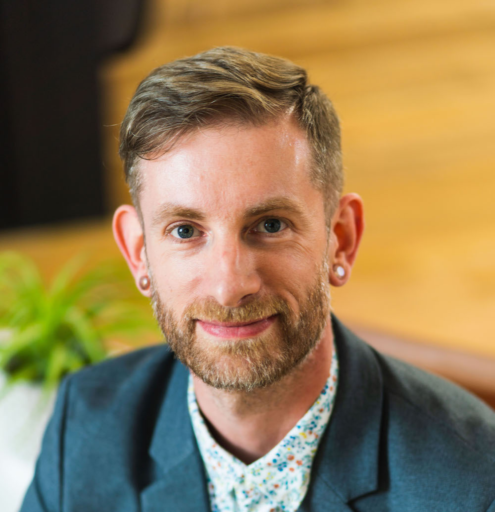

## (gg)plottets anatomi

**A layered grammar of graphics** (Wickham 2008):<sup>1</sup>

1. A default **dataset** and set of mappings from variables to **aesthetics**
2. One or more **layers**, each composed of a **geometric object**, a statistical transformation*<sup>2</sup>, and a position adjustment*, and optionally, a dataset* and aesthetic mappings*
3. One **scale*** for each aesthetic mapping used
4. A **coordinate system***
5. A **faceting*** specification

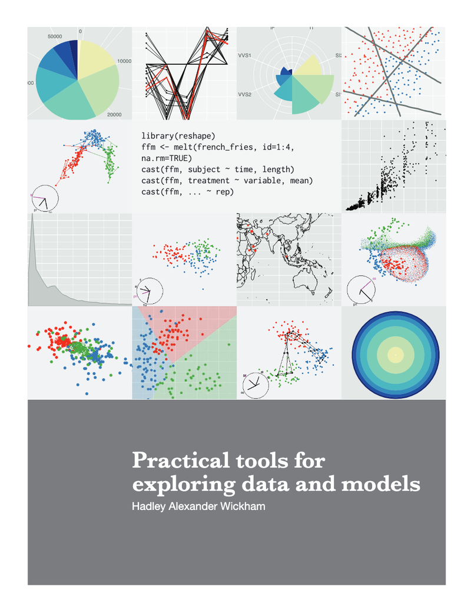

```r
# basalt ggplot call:
data |>                     #1
  ggplot() +
  aes(x = var1, y = var2) + #1
  geom_point() +            #2
  scale_x_continuous() +    #3*
  coord_cartesian() +       #4*
  facet_wrap(~ var3)        #5*

# OBS! der bruges '+' i ggplot
# rækkefølgen er (næsten) underordnet
```

[^2]: Bygger på Wilkinson (2005), ‘The Grammar of Graphics’
[^3]: Alt markeret med * er enten valgfrit eller har gode defaults  
    (specificeres kun, når det skal ændres)

## Eksempel (1)

> A default **dataset** and set of mappings from variables to **aesthetics**

**Kode**

```r
# 1: datasæt
mpg
```

```
# A tibble: 234 × 11
   manufacturer model      displ  year   cyl trans drv     cty   hwy fl    class
   <chr>        <chr>      <dbl> <int> <int> <chr> <chr> <int> <int> <chr> <chr>
 1 audi         a4           1.8  1999     4 auto… f        18    29 p     comp…
 2 audi         a4           1.8  1999     4 manu… f        21    29 p     comp…
 3 audi         a4           2    2008     4 manu… f        20    31 p     comp…
 4 audi         a4           2    2008     4 auto… f        21    30 p     comp…
 5 audi         a4           2.8  1999     6 auto… f        16    26 p     comp…
 6 audi         a4           2.8  1999     6 manu… f        18    26 p     comp…
 7 audi         a4           3.1  2008     6 auto… f        18    27 p     comp…
 8 audi         a4 quattro   1.8  1999     4 manu… 4        18    26 p     comp…
 9 audi         a4 quattro   1.8  1999     4 auto… 4        16    25 p     comp…
10 audi         a4 quattro   2    2008     4 manu… 4        20    28 p     comp…
# ℹ 224 more rows
```

## Eksempel (1)

> A default **dataset** and set of mappings from variables to **aesthetics**

**Kode**

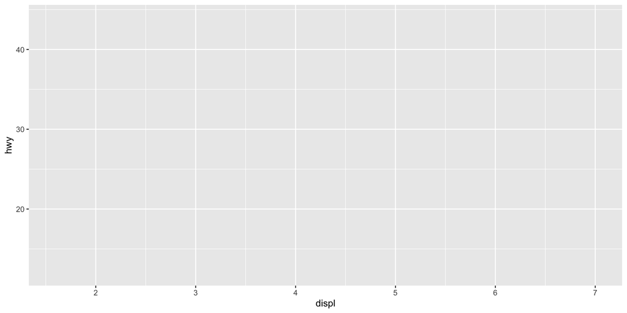

```r
# 1: indlæs ggplot og vælg aesthetics
p1 <- mpg |>
  ggplot() +
  aes(x = displ, y = hwy, color = factor(cyl))

p1
```

## Eksempel (2)

> One or more **layers, each composed of a geometric object**, a statistical transformation*, and a position adjustment*

**Kode**

```r
# 2: lag nr. 1 (geom)
p2 <- p1 +
  geom_point()

p2
```

[output not shown]

## Eksempel (3)

> One **scale*** for each aesthetic mapping used

**Kode**

```r
# 3: skalaer
p3 <- p2 +
  scale_x_continuous() + # default (ingen ændringer)
  scale_y_continuous() + # default (ingen ændringer)
  scale_color_manual(values = c("blue", "yellow", "red", "green")) # vælg farver

p3
```

[output not shown]

## Eksempel (4)

> A **coordinate system***

**Kode**

```r
# 4: koordinatsystem

p4 <- p3 +
  coord_cartesian() # default (ingen ændringer)

p4
```

[output not shown]

Se alle indbyggede koordinatsystemer med ‘ggplot2::coord_’ → [tab] (auto-complete)

## Eksempel (5)

> A **faceting*** specification

**Kode**

```r
# 5: faceting

p5 <- p4 +
  facet_wrap(~ class, nrow = 2) # OBS! Husk en tilde "~" før variablen

p5
```

[figure not shown]

## Eksempel – et geom mere

> One or more **layers, each composed of a geometric object**, a statistical transformation*, and a position adjustment*

**Kode**

```r
# 2: lag nr. 2 (geom)

p6 <- p5 +
  geom_smooth(aes(color = NULL), method = "lm", se = FALSE, color = "black", linewidth = .75, linetype = "dashed")

p6
```

[output not shown]

## Eksempel – koden

```r
# 1: datasæt
mpg

# (1): indlæs ggplot
p0 <- mpg |>
  ggplot()

# 1: aesthetics
p1 <- p0 +
  aes(x = displ, y = hwy, color = factor(cyl))

# 2: lag nr. 1 (geom)
p2 <- p1 +
  geom_point()

# 3: skalaer
p3 <- p2 +
  scale_x_continuous() + # default (ingen ændringer)
  scale_y_continuous() + # default (ingen ændringer)
  scale_color_manual(values = c("blue", "yellow", "red", "green")) # vælg farver

# 4: koordinatsystem

p4 <- p3 +
  coord_cartesian() # default (ingen ændringer)

# 5: faceting

p5 <- p4 +
  facet_wrap(~ class, nrow = 2) # OBS! Husk en tilde "~" før variablen

# 2: lag nr. 2 (geom)

p6 <- p5 +
  geom_smooth(aes(color = NULL), method = "lm", se = FALSE, color = "black", linewidth = .75, linetype = "dashed")

p6
```

## Eksempel – koden: en enkelt chunk

```r
mpg |>
  ggplot() +
  aes(x = displ, y = hwy, color = factor(cyl)) +
  geom_point() +
  geom_smooth(aes(color = NULL), method = "lm", se = FALSE, color = "black", linewidth = .75, linetype = "dashed") +
  scale_color_manual(values = c("blue", "yellow", "red", "green")) +
  facet_wrap(~ class, nrow = 2)
```

## (gg)plottets anatomi

**A layered grammar of graphics** (Wickham 2008):

1. A default **dataset** and set of mappings from variables to **aesthetics**
2. One or more **layers**, each composed of a **geometric object**, a statistical transformation*, and a position adjustment*, and optionally, a dataset* and aesthetic mappings*
3. One **scale*** for each aesthetic mapping used
4. A **coordinate system***
5. A **faceting*** specification

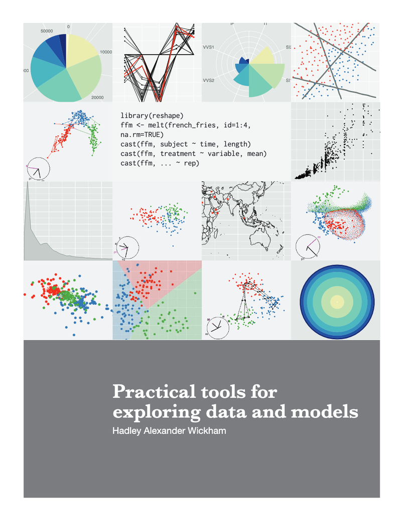

```r
# basalt ggplot call:
data |>                     #1
  ggplot() +
  aes(x = var1, y = var2) + #1
  geom_point() +            #2
  scale_x_continuous() +    #3*
  coord_cartesian() +       #4*
  facet_wrap(~ var3)        #5*

# OBS! der bruges '+' i ggplot
# rækkefølgen er (næsten) underordnet
```

# geoms i ggplot

## geoms (plottyper)

> The direct representation of the data, the **geom**[etric object], is the most important.
- geom_col()
- geom_histogram()
- geom_point(), geom_jitter()
- geom_smooth()
- geom_line()
- geom_hline(), geom_vline()
- geom_text(), geom_label()
- geom_sf()
- geom_ribbon()
- geom_segment()
- … og mange flere

## geom_col(): antal

**Kode**

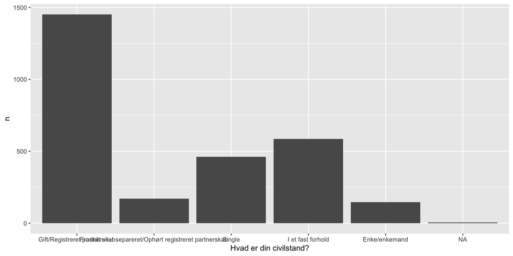

```r
vu |>
  mutate(Q3_labs = to_factor(Q3)) |>
  count(Q3_labs) |>
  ggplot() +
  aes(x = Q3_labs, y = n) +
  geom_col()
```

## geom_col(): andel

**Kode**

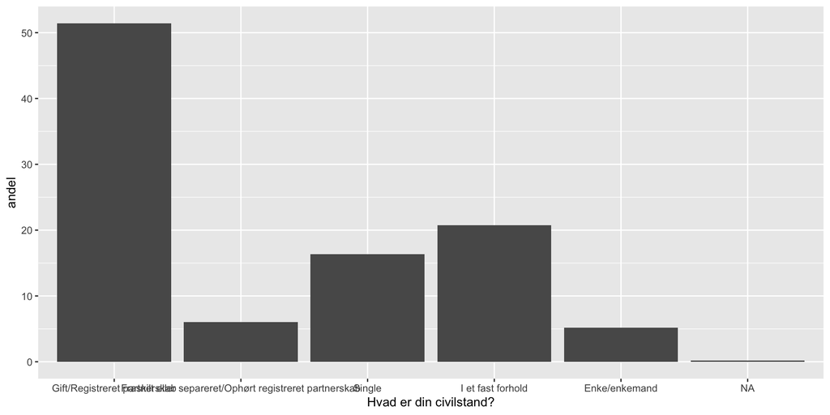

```r
vu |>
  mutate(Q3_labs = to_factor(Q3)) |>
  count(Q3_labs) |>
  mutate(andel = n / sum(n) * 100) |>
  ggplot() +
  aes(x = Q3_labs, y = andel) +
  geom_col()
```

## geom_col(): andel + 90 grader

**Kode**

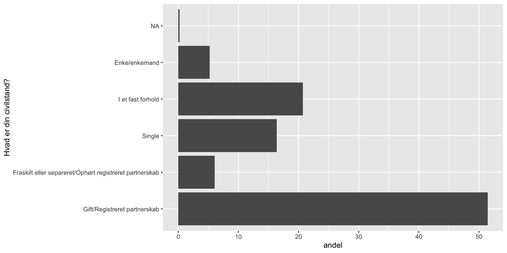

```r
vu |>
  mutate(Q3_labs = to_factor(Q3)) |>
  count(Q3_labs) |>
  mutate(andel = n / sum(n) * 100) |>
  ggplot() +
  aes(x = Q3_labs, y = andel) +
  geom_col() +
  coord_flip()
```

## geom_col(): andel + 90 grader + sorteret

**Kode**

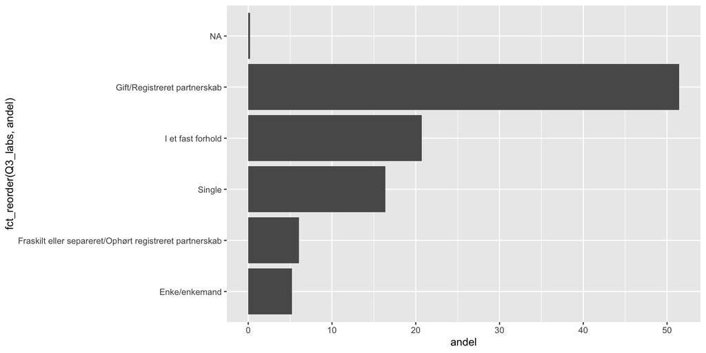

```r
vu |>
  mutate(Q3_labs = to_factor(Q3)) |>
  count(Q3_labs) |>
  mutate(andel = n / sum(n) * 100) |>
  ggplot() +
  aes(x = fct_reorder(Q3_labs, andel), y = andel) +
  geom_col() +
  coord_flip()
```

## geom_col(): andel + 90 grader + sorteret + fill (køn)

**Kode**

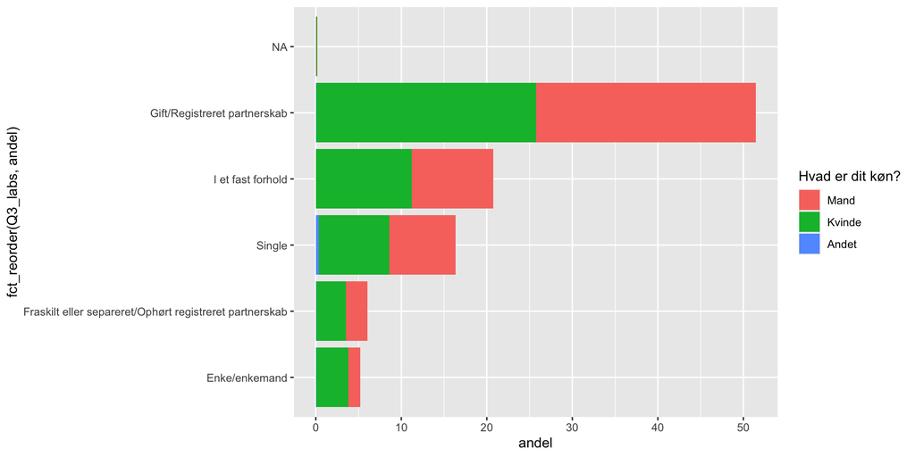

```r
vu |>
  mutate(Q3_labs = to_factor(Q3), gender = to_factor(gender)) |>
  count(Q3_labs, gender) |>
  mutate(andel = n / sum(n) * 100) |>
  ggplot() +
  aes(x = fct_reorder(Q3_labs, andel), y = andel, fill = gender) +
  geom_col() +
  coord_flip()
```

## geom_col(): … + position_fill()

**Kode**

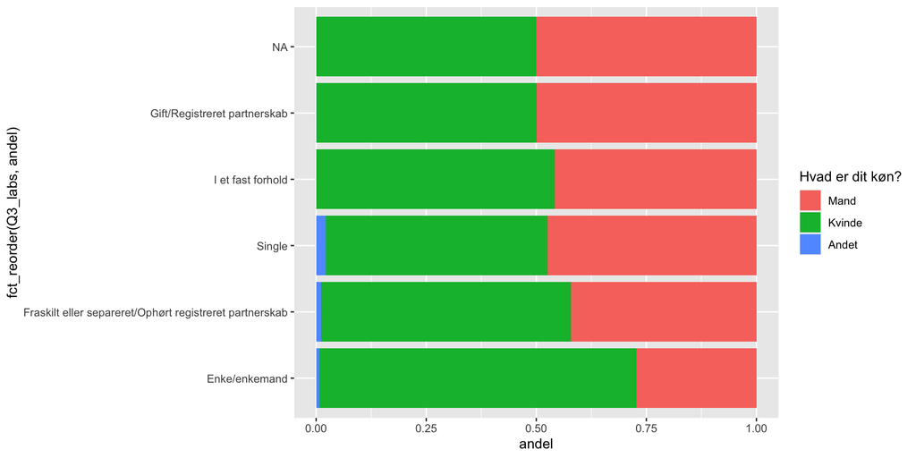

```r
vu |>
  mutate(Q3_labs = to_factor(Q3), gender = to_factor(gender)) |>
  count(Q3_labs, gender) |>
  mutate(andel = n / sum(n) * 100) |>
  ggplot() +
  aes(x = fct_reorder(Q3_labs, andel), y = andel, fill = gender) +
  geom_col(position = position_fill()) +
  coord_flip()
```

## geom_col(): … + position_dodge()

**Kode**

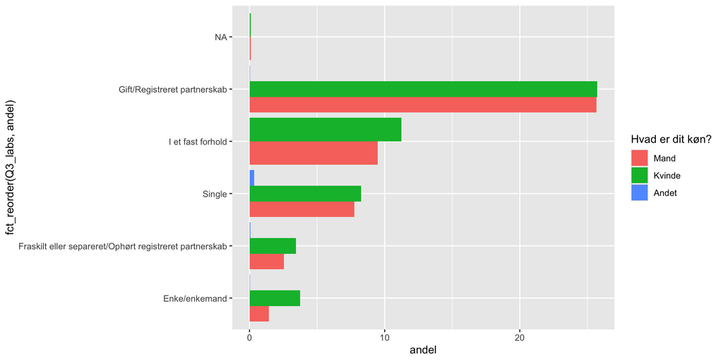

```r
vu |>
  mutate(Q3_labs = to_factor(Q3), gender = to_factor(gender)) |>
  count(Q3_labs, gender) |>
  mutate(andel = n / sum(n) * 100) |>
  ggplot() +
  aes(x = fct_reorder(Q3_labs, andel), y = andel, fill = gender) +
  geom_col(position = position_dodge()) +
  coord_flip()
```

## geom_histogram()

**Kode**

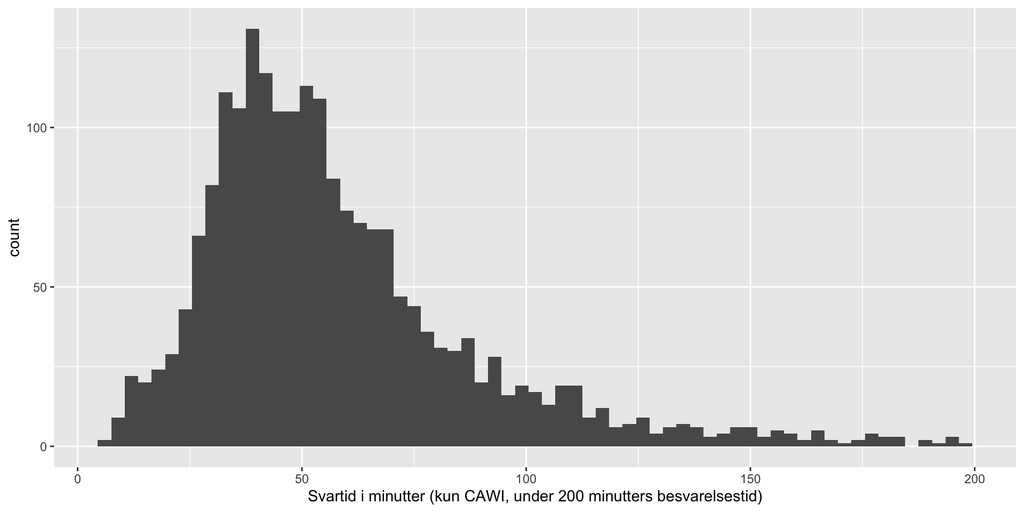

```r
vu |>
  ggplot() +
  aes(x = lenght) +
  geom_histogram(binwidth = 3)
```

## geom_density()

**Kode**

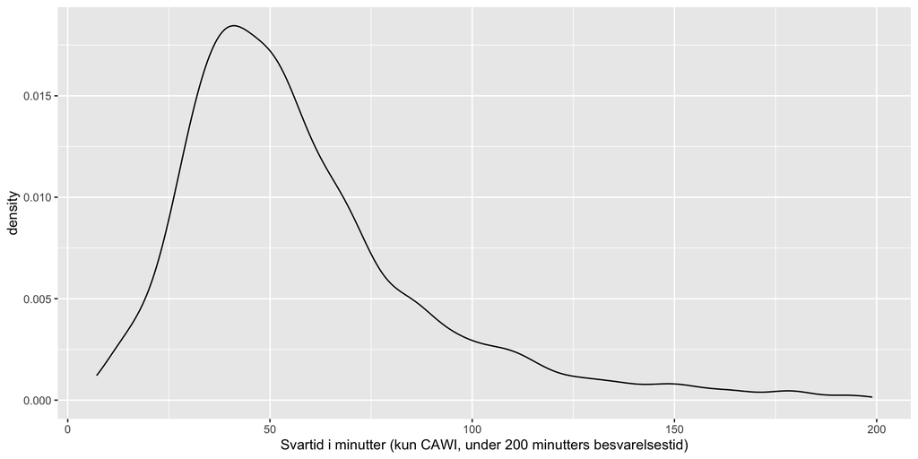

```r
vu |>
  ggplot() +
  aes(x = lenght) +
  geom_density()
```

## geom_boxplot()

**Kode**

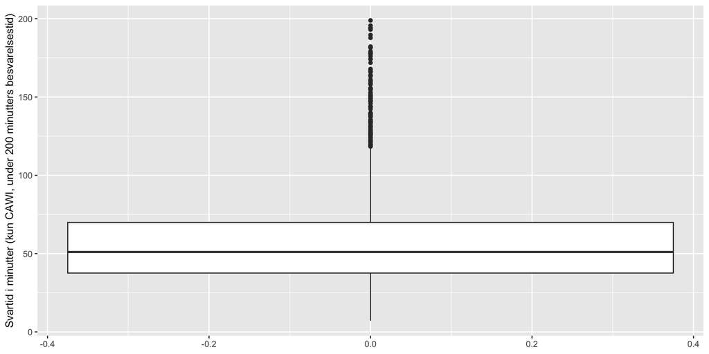

```r
vu |>
  ggplot() +
  aes(y = lenght) +
  geom_boxplot()
```

## geom_boxplot()

**Kode**

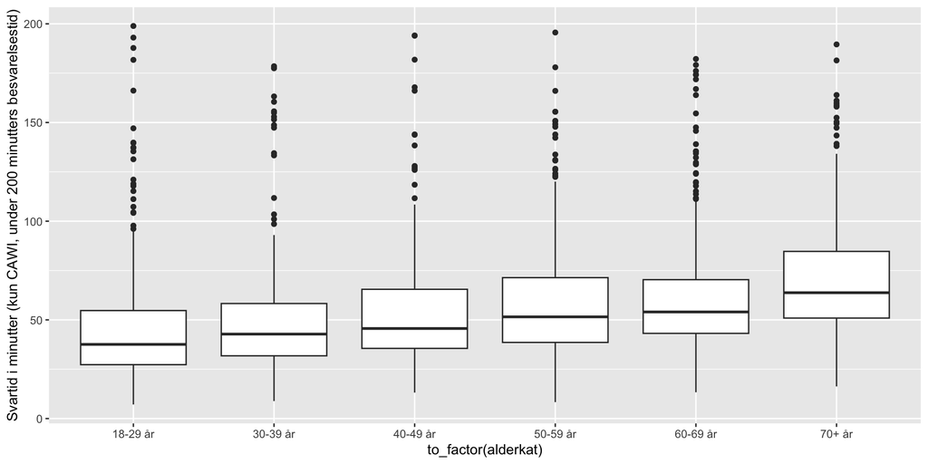

```r
vu |>
  ggplot() +
  aes(x = to_factor(alderkat),  y = lenght) +
  geom_boxplot()
```

## geom_point()

**Kode**

```r
mpg |>
  ggplot() +
  aes(x = displ, y = hwy, color = factor(cyl)) +
  geom_point()
```

[output not shown]

## geom_point()

**Q44_2:** Økonomi (1 bedre - 5 dårligere)<sup>1</sup>  
**Q51_1:** Klimaudfordring (1 enig - 5 uenig)<sup>2</sup>

[^4]: Hvordan tror du, den økonomiske situation for Danmark vil være om 3 år sammenlignet med i dag
[^5]: Klimaforandringerne er vor tids største udfordring

## geom_point()

**Q44_2:** Økonomi (1 bedre - 5 dårligere)  
**Q51_1:** Klimaudfordring (1 enig - 5 uenig)

**Kode**

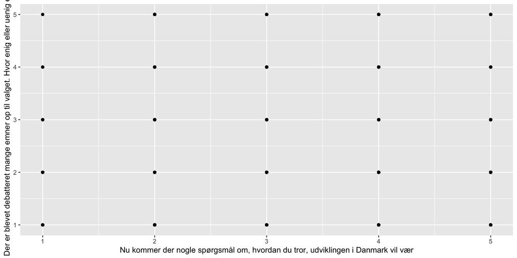

```r
vu |>
  filter(Q44_2 %in% 1:5, Q51_1 %in% 1:5) |> # behold kun ikke-missing
  ggplot() +
  aes(x = Q44_2, y = Q51_1) +
  geom_point()
```

*Hvorfor ser det så mærkeligt ud?*

## geom_point() + jitter

**Q44_2:** Økonomi (1 bedre - 5 dårligere)  
**Q51_1:** Klimaudfordring (1 enig - 5 uenig)

**Kode**

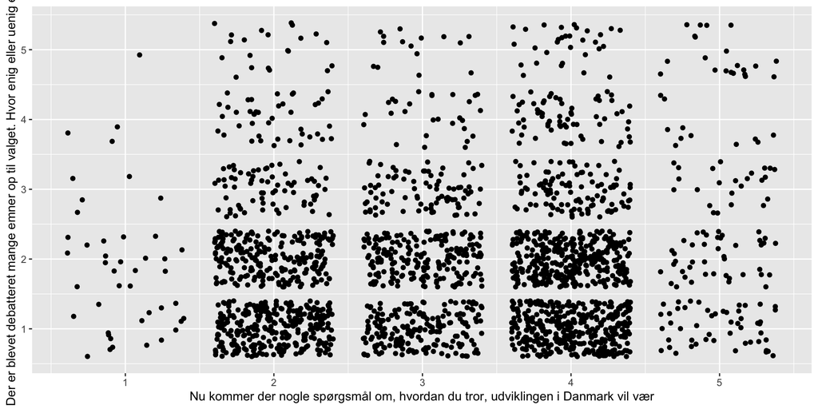

```r
vu |>
  filter(Q44_2 %in% 1:5, Q51_1 %in% 1:5) |> # behold kun ikke-missing
  ggplot() +
  aes(x = Q44_2, y = Q51_1) +
  geom_jitter()
```

## geom_point() + jitter + geom_smooth(method = “lm”)

**Q44_2:** Økonomi (1 bedre - 5 dårligere)  
**Q51_1:** Klimaudfordring (1 enig - 5 uenig)

**Kode**

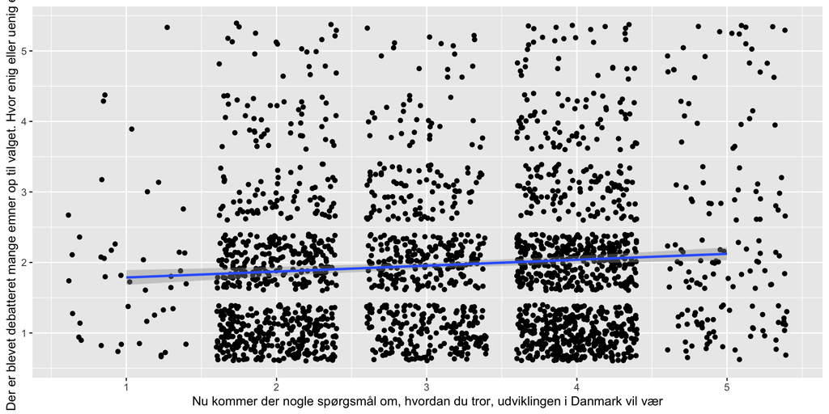

```r
vu |>
  filter(Q44_2 %in% 1:5, Q51_1 %in% 1:5) |> # behold kun ikke-missing
  ggplot() +
  aes(x = Q44_2, y = Q51_1) +
  geom_jitter() +
  geom_smooth(method = "lm") # linear model
```

## geom_point() + jitter + geom_smooth(method = “loess”)

**Q44_2:** Økonomi (1 bedre - 5 dårligere)  
**Q51_1:** Klimaudfordring (1 enig - 5 uenig)

**Kode**

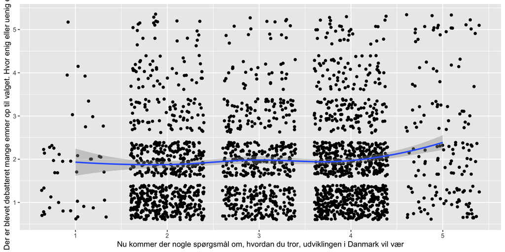

```r
vu |>
  filter(Q44_2 %in% 1:5, Q51_1 %in% 1:5) |> # behold kun ikke-missing
  ggplot() +
  aes(x = Q44_2, y = Q51_1) +
  geom_jitter() +
  geom_smooth(method = "loess") # local averages
```

## geom_line()

**Kode**

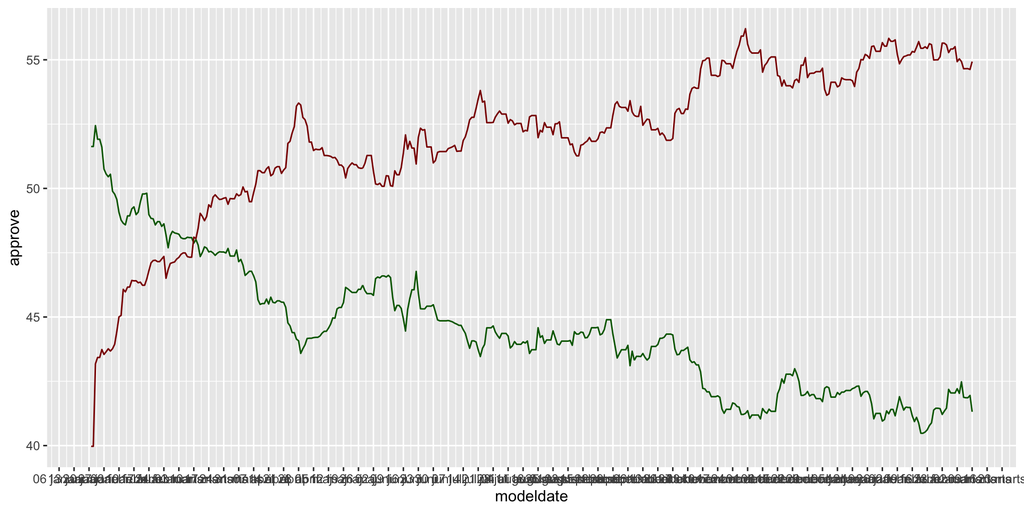

US Presidential approval ratings. Data: Silver & McKown-Dawson (2025) @ https://www.natesilver.net/p/trump-approval-ratings-nate-silver-bulletin

```r
ar <- read_csv("https://static.dwcdn.net/data/kSCt4.csv?v=1741596780000") |>
  mutate(modeldate = mdy(modeldate)) # fortæl R at modeldate er en dato (måned/dag/år)

ar |>
  ggplot() +
  aes(x = modeldate) +
  geom_line(aes(y = approve), color = "darkgreen") +
  geom_line(aes(y = disapprove), color = "darkred") +
  scale_x_date(date_breaks = "1 week", date_labels = "%d %B")
```

## geom_line() + geom_hline(), geom_vline()

**Kode**

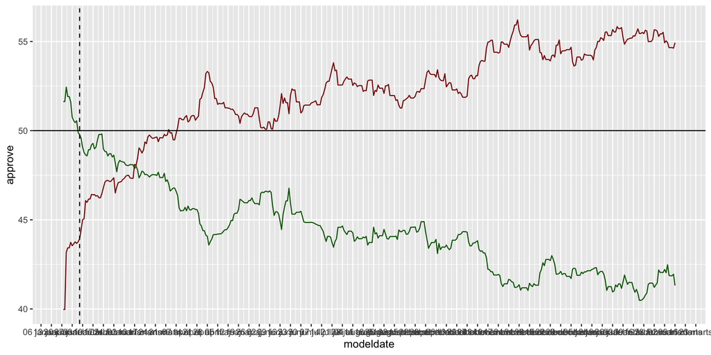

US Presidential approval ratings. Data: Silver & McKown-Dawson (2025) @ https://www.natesilver.net/p/trump-approval-ratings-nate-silver-bulletin

```r
ar |>
  ggplot() +
  aes(x = modeldate) +
  geom_line(aes(y = approve), color = "darkgreen") +
  geom_line(aes(y = disapprove), color = "darkred") +
  scale_x_date(date_breaks = "1 week", date_labels = "%d %B") +
  geom_hline(aes(yintercept = 50)) +
  geom_vline(aes(xintercept = ymd("20250201")), linetype = "dashed")
```

## geom_line() + geom_hline(), geom_vline() + geom_text()

**Kode**

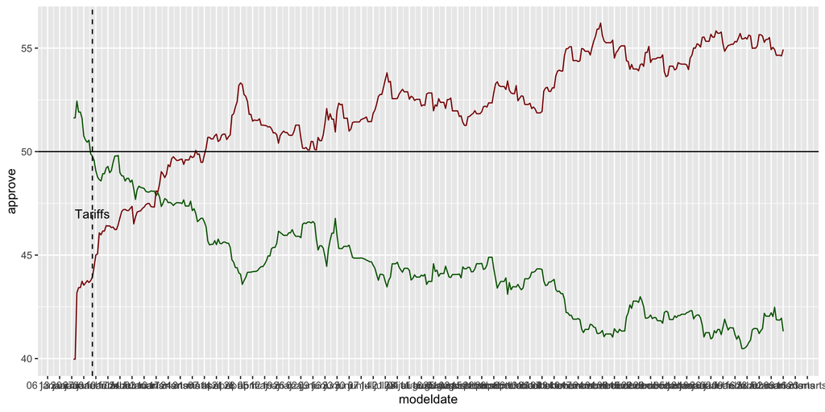

US Presidential approval ratings. Data: Silver & McKown-Dawson (2025) @ https://www.natesilver.net/p/trump-approval-ratings-nate-silver-bulletin

```r
ar |>
  ggplot() +
  aes(x = modeldate) +
  geom_line(aes(y = approve), color = "darkgreen") +
  geom_line(aes(y = disapprove), color = "darkred") +
  scale_x_date(date_breaks = "1 week", date_labels = "%d %B") +
  geom_hline(aes(yintercept = 50)) +
  geom_vline(aes(xintercept = ymd("20250201")), linetype = "dashed") +
  geom_text(aes(label = "Tariffs", x = ymd("20250201"), y = 47), check_overlap = TRUE) # 'check_overlap = TRUE' er sommetider pænere
```

## geom_sf() – kort

**Kode**

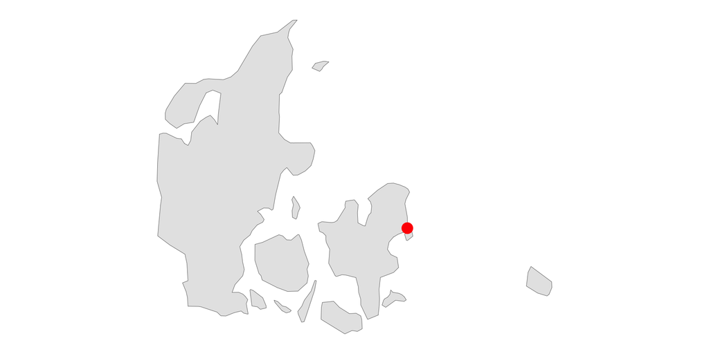

```r
library(sf)
library(rnaturalearth)
library(ggthemes)

map_data <- rnaturalearth::ne_countries(country = "Denmark", scale = "medium") |> # hent data
  st_as_sf() # gør data geografiske med sf-pakken

map_data |>
  ggplot() +
  geom_sf() +
  geom_point(aes(x = longitude, y = latitude), size = 5, color = "red", data = tibble(longitude = 12.5683, latitude = 55.6761)) +
  theme_map()
```

Se alle indbyggede geoms med ‘ggplot2::geom_’ → [tab] (auto-complete)

## Aesthetics – `aes()`

*Mapping:* hvilke **variable** styrer hvilke visuelle **parametre**?

**Kode**

```r
data +
  ggplot() +
  aes(x = var1,
      y = var2,
      color = var3,
      fill = var4,
      size = var5,
      shape = var6,
      linetype = var7,
      alpha = var8) +
geom_*()
```

- De fleste visuelle parametre (aesthetics) kan “styres” af værdien på en variabel
  - også *width*, *linewidth*, *xmin*, *xmax*, *ymin*, *ymax* osv. osv.
  - hvilke aesthetics der giver mening afhænger af geom’et
- Vi bruger næsten altid *x* og/eller *y* (position)
  - ofte 1-2 andre (fx farver)

## Aesthetics – `aes()`

- Parametrene (fx farve) kan også fastsættes direkte i geom_* uden aes()
  - → så er det en konstant, ikke variabel

**Kode**

```r
mpg |>
  ggplot() +
  aes(x = displ, y = hwy, color = factor(cyl)) +
  geom_point()
```

[output not shown]

Variablen cyl styrer punkternes farve

**Kode**

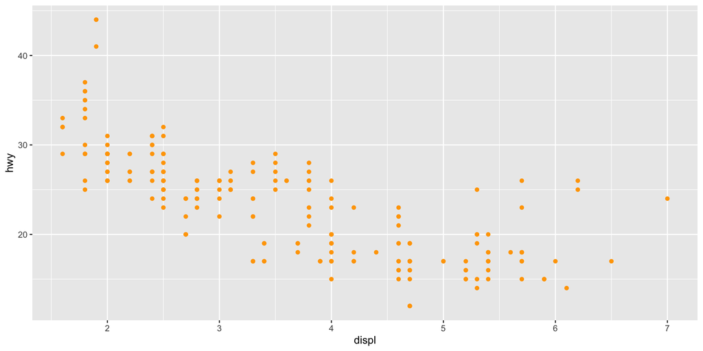

Alle punkternes farve skal være orange

```r
mpg |>
  ggplot() +
  aes(x = displ, y = hwy) +
  geom_point(color = "orange")
```

## Facets

- Flere små plots → smart!
- Ofte bedste løsning, når vi er over 3 variable (aesthetics) på ét plot
  - nogle gange også ved 1-2 variable
- Enkel **syntaks**: (p +) `facet_wrap(~ facet_var)`
  - *scales* = “free”, “free_x”, “free_y”
  - *nrow* eller *ncol* = antal rækker/kolonner

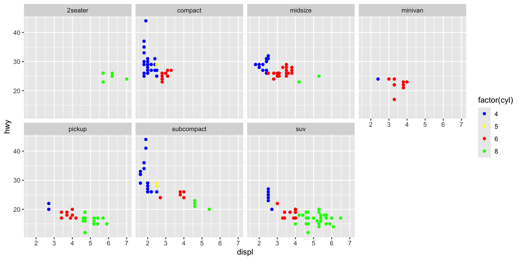